# 動画から背景画像を消す処理

公式チュートリアル（英語）：https://docs.opencv.org/4.0.0/d6/d00/tutorial_py_root.html

背景差分を表示するチュートリアルサンプル：https://docs.opencv.org/4.0.0/db/d5c/tutorial_py_bg_subtraction.html

## ストーリー(再掲)

以下のプログラムはネットに落ちていたプログラムだと考えてください

とりあえず実行できましたが，仕様書（課題文）の達成に役に立つのかどうかわかりません

役に立つか判断するため，プログラム内で使われている関数やデータ構造を調べていきましょう．

lecture07_BackgroundSubtraction.py

```python
#!/usr/bin/env python
# -*- coding: utf-8 -*-

import numpy as np
import cv2

cap = cv2.VideoCapture(0)
cap.set(cv2.CAP_PROP_FRAME_WIDTH, 640)
cap.set(cv2.CAP_PROP_FRAME_HEIGHT, 480)
fgbg = cv2.createBackgroundSubtractorMOG2(history=500, varThreshold=16, detectShadows=True)
while(True):
    ret, frame = cap.read()
    resized_frame = cv2.resize(frame, (640,480))
    fgmask = fgbg.apply(frame)
    cv2.imshow('frame',fgmask)
    k = cv2.waitKey(30) & 0xff
    if k == 27:
        print(type(fgmask))
        print(fgmask.shape)
        print(fgmask[0:10,0:10])
        break # 'ESC' key is pressed
cap.release()
cv2.destroyAllWindows()
```

# 表示例

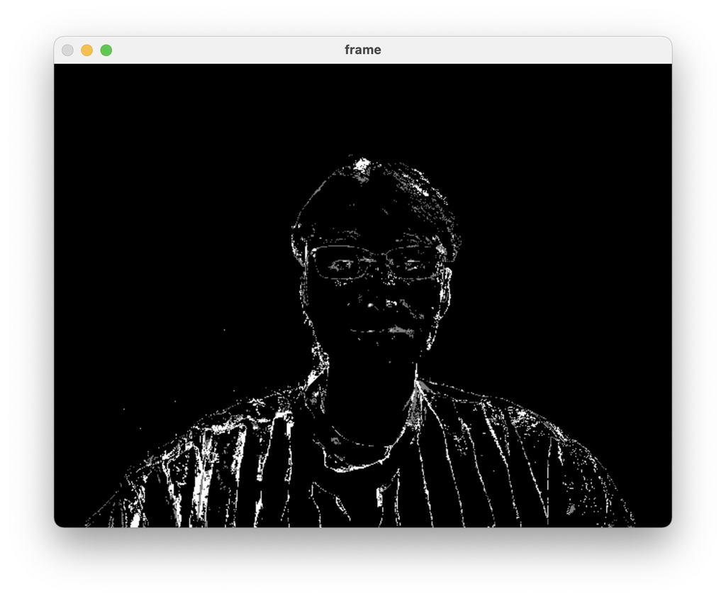

# 解説

動画は画像を時間変化させたもので，画像の変化している箇所と変化していない箇所を区別するプログラムのようだ

`fgbg.apply()`関数が返すfgmaskオブジェクトを`cv.imshow()`関数で使うと動いているところだけが白色になるように見える

上記関数やオブジェクトの中身が分かればzoomなどの動画配信で背景を消すアプリに利用できるかもしれない

というのは乱暴なので，このプログラムでも調べられることに触れておきます

以下のプログラムをESCキーを押したときに実行してみましょう

```python
print(type(fgmask))
print(fgmask.shape)
print(fgmask[0:10,0:10])
```

実行結果

```bash
<class 'numpy.ndarray'>
(480, 640)
[[0 0 0 0 0 0 0 0 0 0]
 [0 0 0 0 0 0 0 0 0 0]
 [0 0 0 0 0 0 0 0 0 0]
 [0 0 0 0 0 0 0 0 0 0]
 [0 0 0 0 0 0 0 0 0 0]
 [0 0 0 0 0 0 0 0 0 0]
 [0 0 0 0 0 0 0 0 0 0]
 [0 0 0 0 0 0 0 0 0 0]
 [0 0 0 0 0 0 0 0 127 0]
 [0 0 0 0 0 0 0 255 0 0]]
```

fgmaskオブジェクトの中身はnumpy.ndarray，またもや画像であることがわかりました

画像の中身（左上から幅10px・縦10px）を見てみると，0（黒）,127（グレー）もしくは255(白)が並んでいます

maskという名前がついていることからこのmask画像を使って特定の領域だけを表示することができそうです

# まとめ

OpenCVで動きのあるピクセルだけを表示するサンプルを紹介した

プログラムの内容理解のために，次の資料でも関数やデータ構造を調べていくことにする